# SIG04 DEG visualizations

Eric Y. Wang

2024-10-02

```r
source("functions/plotting_fxns.R")
source("functions/scRNA_seq_analysis_functions.R")
theme_set(theme_Publication())
```

## Import dataSinglet

```r
# import seurat object and subset to singlets
data <- readRDS("C:/Users/Eric/Documents/datasets/EYW/SIG04_10x_240816/seurat_outs/SIG04_postqc_seurat.rds")

dataSinglet <- subset(data, subset = oBC_classification == "singlet")
```

```r
meta <- read_csv("processing_outs/plate_meta_SIG04.csv")
```

## Background Barcode Expression

Here, I want to see if the CRISPR algorithm is undercalling barcodes. I’ll take a look at the max BC count for cells that were not called by the algorithm.

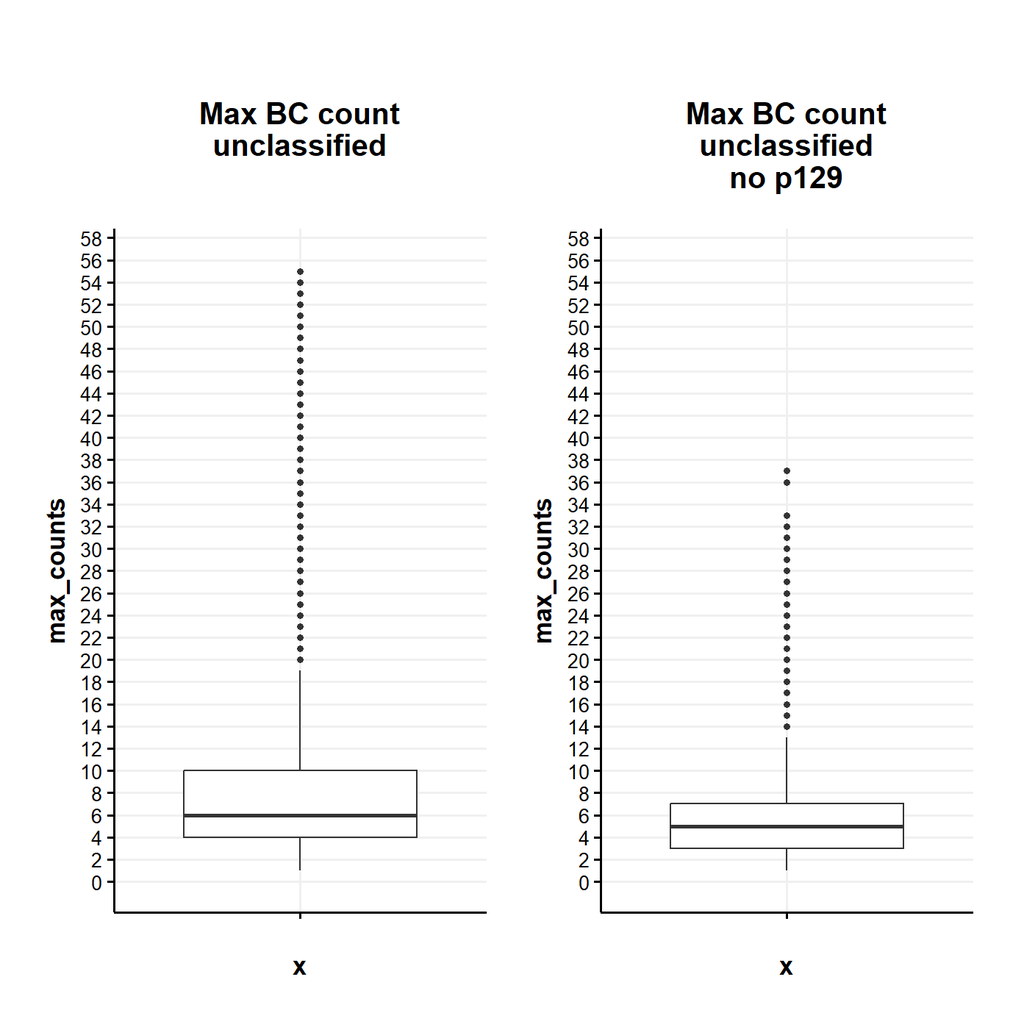

```r
metadata <- data@meta.data %>%
  as_tibble(rownames = "cell_bc")

# extract raw umi counts and add feature call metadata
counts <- GetAssayData(data, assay = "oBC", layer = "counts") %>%
  as_tibble(rownames = "ligand") %>%
  pivot_longer(-ligand, names_to = "cell_bc", values_to = "expression") %>%
  left_join(metadata, by="cell_bc") %>%
  filter(gem_group == "lane1") %>%
  filter(oBC_classification == "none")

p1 <- counts %>%
  group_by(cell_bc) %>%
  summarise(max_counts = max(expression)) %>%
  ggplot(aes(x="",y=max_counts)) +
    geom_boxplot() +
    scale_y_continuous(breaks = seq(0,60,2), limits = c(0,56)) +
    ggtitle("Max BC count\nunclassified")

p2 <- counts %>%
  group_by(cell_bc) %>%
  filter(ligand != "p129") %>%
  summarise(max_counts = max(expression)) %>%
  ggplot(aes(x="",y=max_counts)) +
    geom_boxplot() +
    scale_y_continuous(breaks = seq(0,60,2), limits = c(0,56)) +
    ggtitle("Max BC count\nunclassified\nno p129")

p1+p2
```

```r
maxCounts <- counts %>%
  filter(ligand != "p129") %>%
  group_by(cell_bc) %>%
  summarise(max_counts = max(expression))

maxCounts
```

| cell_bc | max_counts |
| --- | --- |
| lane1_AAACCAAAGACATGCC-1 | 7 |
| lane1_AAACCAAAGACCAGAG-1 | 11 |
| lane1_AAACCAAAGAGGACCA-1 | 4 |
| lane1_AAACCAAAGCAATTAC-1 | 3 |
| lane1_AAACCAAAGGCAGGGT-1 | 4 |
| lane1_AAACCAAAGGTAAGCG-1 | 17 |
| lane1_AAACCAGCAAAGTGCA-1 | 6 |
| lane1_AAACCATTCACTCCCA-1 | 3 |
| lane1_AAACCATTCATAGCAT-1 | 3 |
| lane1_AAACCATTCGCCATAA-1 | 3 |

[output cut: 990 more lines]

[figure not shown]

There are definitely some cells where a call could probably be made. I think looking at the UMI cutoffs used by the some of the cells could be called. Perhaps something to look into in the future.

## Barcode Expression Heatmap (Singlets)

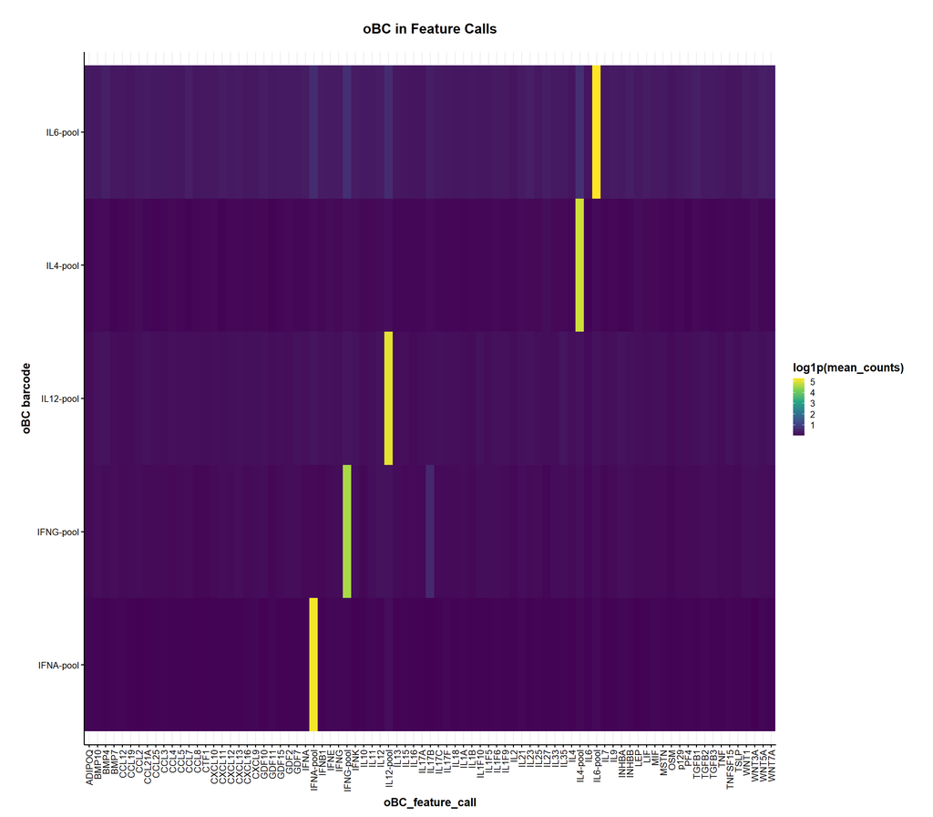

```r
metadata <- dataSinglet@meta.data %>%
  as_tibble(rownames = "cell_bc")

# extract CLR normalized counts and add feature call metadata
normCounts <- GetAssayData(dataSinglet, assay = "oBC", layer = "counts") %>%
  as_tibble(rownames = "ligand") %>%
  filter(grepl("-pool",ligand)) %>%
  pivot_longer(-ligand, names_to = "cell_bc", values_to = "expression") %>%
  left_join(metadata, by="cell_bc")

# summarize mean expression
summaryCounts <- normCounts %>%
  group_by(oBC_feature_call, ligand) %>%
  summarise(mean_counts = mean(expression))
summaryCounts %>%
  ggplot(aes(x=oBC_feature_call,y=ligand,fill=log1p(mean_counts))) +
    geom_tile() +
    ylab("oBC barcode") +
    scale_fill_viridis_c() +
    ggtitle("oBC in Feature Calls") +
    theme(aspect.ratio = 1,
          axis.text.x = element_text(angle = 90, vjust = 0.5, hjust=1))
```

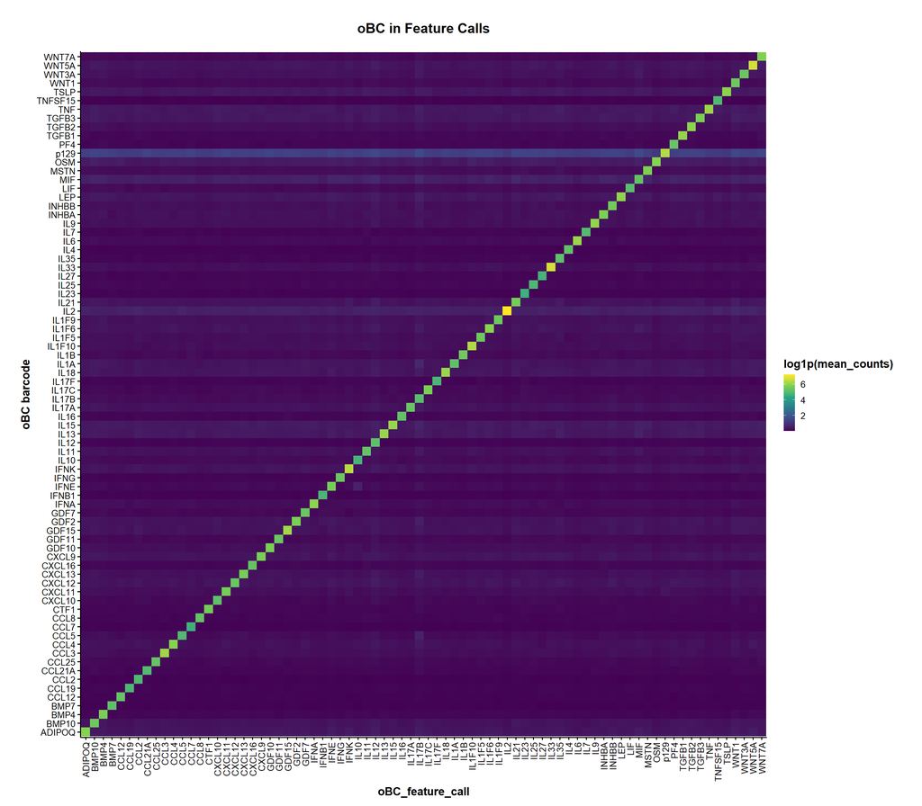

```r
metadata <- dataSinglet@meta.data %>%
  as_tibble(rownames = "cell_bc")

# extract CLR normalized counts and add feature call metadata
normCounts <- GetAssayData(dataSinglet, assay = "oBC", layer = "counts") %>%
  as_tibble(rownames = "ligand") %>%
  filter(!grepl("-pool",ligand)) %>%
  pivot_longer(-ligand, names_to = "cell_bc", values_to = "expression") %>%
  left_join(metadata, by="cell_bc") %>%
  filter(!grepl("-pool",oBC_feature_call))

# summarize mean expression
summaryCounts <- normCounts %>%
  group_by(oBC_feature_call, ligand) %>%
  summarise(mean_counts = mean(expression))
summaryCounts %>%
  ggplot(aes(x=oBC_feature_call,y=ligand,fill=log1p(mean_counts))) +
    geom_tile() +
    ylab("oBC barcode") +
    scale_fill_viridis_c() +
    ggtitle("oBC in Feature Calls") +
    theme(aspect.ratio = 1,
          axis.text.x = element_text(angle = 90, vjust = 0.5, hjust=1))
```

## Barcode MFI correlations

First, lets see if barcode counts correlate with mBaoJin MFI by flow. I am mainly concerned with whether there is some independent assortment of barcode containing virus and ligand displaying virus.

We’ll filter to only include cells from lane 1 because lane 2 was sorted so it’s not really representative of raw MFI -> barcode correlations

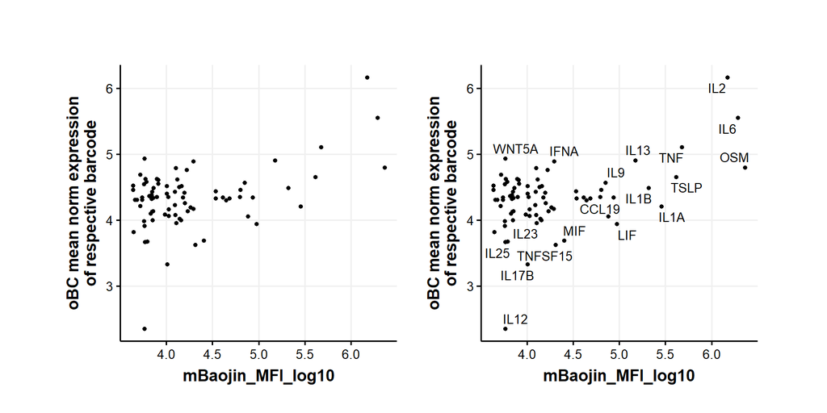

```r
metadata <- dataSinglet@meta.data %>%
  as_tibble(rownames = "cell_bc")

# extract CLR normalized counts and add feature call metadata
normCounts <- GetAssayData(dataSinglet, assay = "oBC", layer = "data") %>%
  as_tibble(rownames = "ligand") %>%
  pivot_longer(-ligand, names_to = "cell_bc", values_to = "expression") %>%
  left_join(metadata, by="cell_bc")

# summarize mean expression
# filter by lane 1
summaryCounts <- normCounts %>%
  filter(gem_group == "lane1") %>%
  group_by(oBC_feature_call, ligand) %>%
  summarise(mean_counts = mean(expression),
            mean_log1p_umi = mean(oBC_log1p_total_counts))
# join summary counts from above with MFI
# filter to only include matching feature_call ligand pairs
summaryCountsCalled <- summaryCounts %>%
  left_join(meta, by="oBC_feature_call") %>%
  filter(oBC_feature_call == ligand)

p1 <- summaryCountsCalled %>%
  ggplot(aes(x=mBaojin_MFI_log10,y=mean_counts)) +
    geom_point() +
    ylab("oBC mean norm expression\nof respective barcode") +
    theme(aspect.ratio = 1)

p2 <- summaryCountsCalled %>%
  ggplot(aes(x=mBaojin_MFI_log10,y=mean_counts)) +
    geom_point() +
    geom_text_repel(aes(label = oBC_feature_call)) +
    ylab("oBC mean norm expression\nof respective barcode") +
    theme(aspect.ratio = 1)

p1+p2
```

There’s a good trend with flow MFI and barcode detection. IL12 is kind of an outlier which maybe explains why I didn’t see anything in the perturbation.

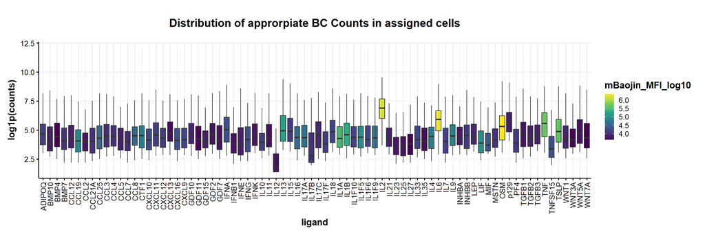

```r
metadata <- dataSinglet@meta.data %>%
  as_tibble(rownames = "cell_bc")

# extract raw umi counts and add feature call metadata
counts <- GetAssayData(dataSinglet, assay = "oBC", layer = "counts") %>%
  as_tibble(rownames = "ligand") %>%
  pivot_longer(-ligand, names_to = "cell_bc", values_to = "counts") %>%
  left_join(metadata, by="cell_bc") %>%
  filter(gem_group == "lane1") %>%
  filter(oBC_feature_call == ligand) %>%
  left_join(meta, by="oBC_feature_call") %>%
  filter(!grepl("-pool",ligand))

ggplot(counts, aes(x=ligand,y=log1p(counts), fill = mBaojin_MFI_log10)) +
  geom_boxplot(outlier.shape = NA) +
  scale_fill_viridis_c() +
  theme(axis.text.x = element_text(angle = 90, vjust = 0.5, hjust=1)) +
  ggtitle("Distribution of approrpiate BC Counts in assigned cells")
```

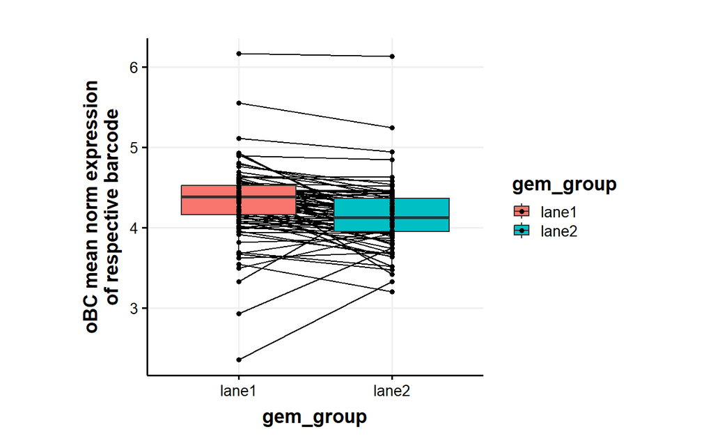

```r
# summarize mean expression
# filter by lane 1
summaryCounts <- normCounts %>%
  group_by(gem_group) %>%
  mutate(mean_gem_group = mean(expression)) %>%
  group_by(gem_group, oBC_feature_call, ligand) %>%
  summarise(mean_exp = mean(expression),
            mean_norm_exp = mean(expression)-mean_gem_group)
# join summary counts from above with MFI
# filter to only include matching feature_call ligand pairs
summaryCountsCalled <- summaryCounts %>%
  left_join(meta, by="oBC_feature_call") %>%
  filter(oBC_feature_call == ligand)

summaryCountsCalled %>%
  ggplot(aes(x = gem_group, y = mean_exp, fill = gem_group)) +
    geom_line(aes(group = oBC_feature_call)) +
    geom_boxplot() +
    geom_point() +
    ylab("oBC mean norm expression\nof respective barcode") +
    theme(aspect.ratio = 1)
```

As expected lane 2, which is flow sorted for mBaoJin+ cells has a tighter distribution especially towards the bottom end. *They’re not that different though which is interesting (some level of independence between display and viral uptake?)* The distributions are a bit shifted because the lane 2 amplification of oBC was worse for some reason.

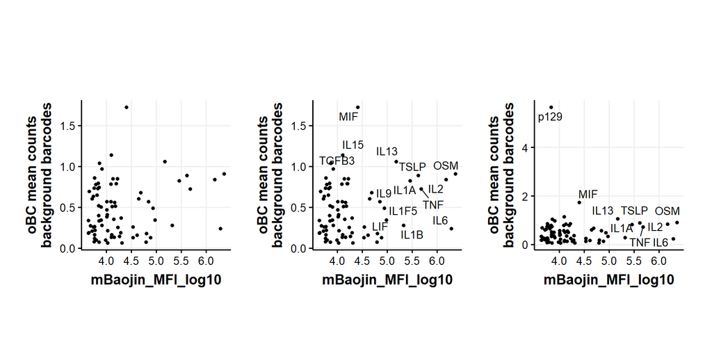

```r
p1 <- summaryCounts %>%
  filter(ligand != "p129") %>%
  ggplot(aes(x=mBaojin_MFI_log10,y=mean_exp)) +
    geom_point() +
    ylab("oBC mean counts\nbackground barcodes") +
    theme(aspect.ratio = 1)

p2 <- summaryCounts %>%
  filter(ligand != "p129") %>%
  ggplot(aes(x=mBaojin_MFI_log10,y=mean_exp)) +
    geom_point() +
    geom_text_repel(aes(label = ligand)) +
    ylab("oBC mean counts\nbackground barcodes") +
    theme(aspect.ratio = 1)

p3 <- summaryCounts %>%
  ggplot(aes(x=mBaojin_MFI_log10,y=mean_exp)) +
    geom_point() +
    geom_text_repel(aes(label = ligand)) +
    ylab("oBC mean counts\nbackground barcodes") +
    theme(aspect.ratio = 1)

p1+p2+p3
```

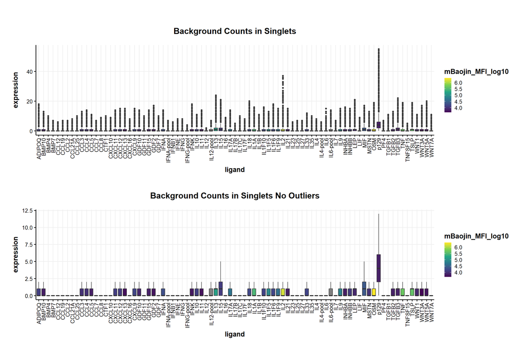

```r
metadata <- dataSinglet@meta.data %>%
  as_tibble(rownames = "cell_bc")

# extract raw umi counts and add feature call metadata
counts <- GetAssayData(dataSinglet, assay = "oBC", layer = "counts") %>%
  as_tibble(rownames = "ligand") %>%
  pivot_longer(-ligand, names_to = "cell_bc", values_to = "expression") %>%
  left_join(metadata, by="cell_bc") %>%
  filter(gem_group == "lane1") %>%
  filter(oBC_feature_call != ligand) %>%
  left_join(meta, by=c("ligand"="oBC_feature_call"))

p1 <- ggplot(counts, aes(x=ligand,y=expression, fill = mBaojin_MFI_log10)) +
  geom_boxplot() +
  #ylim(0,12)+
  scale_fill_viridis_c() +
  theme(axis.text.x = element_text(angle = 90, vjust = 0.5, hjust=1)) +
  ggtitle("Background Counts in Singlets")

p2 <- ggplot(counts, aes(x=ligand,y=expression, fill = mBaojin_MFI_log10)) +
  geom_boxplot(outlier.shape = NA) +
  ylim(0,12)+
  scale_fill_viridis_c() +
  theme(axis.text.x = element_text(angle = 90, vjust = 0.5, hjust=1)) +
  ggtitle("Background Counts in Singlets No Outliers")

p1/p2
```

## Guide Call MFI correlations

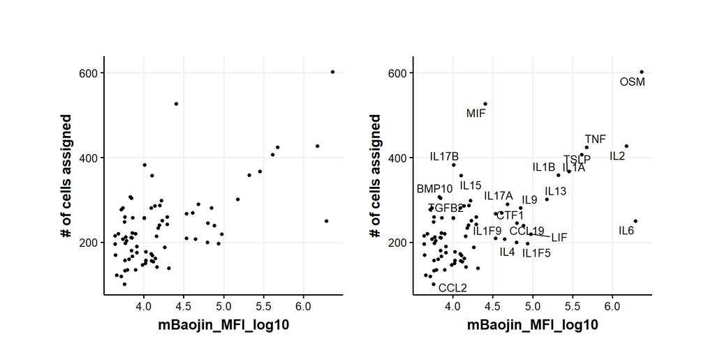

```r
metadata <- dataSinglet@meta.data %>%
  as_tibble(rownames = "cell_bc")

# extract CLR normalized counts and add feature call metadata
normCounts <- GetAssayData(dataSinglet, assay = "oBC", layer = "data") %>%
  as_tibble(rownames = "ligand") %>%
  pivot_longer(-ligand, names_to = "cell_bc", values_to = "expression") %>%
  left_join(metadata, by="cell_bc")

# summarize mean expression
# filter by lane 1
summaryCounts <- normCounts %>%
  filter(gem_group == "lane1") %>%
  filter(oBC_feature_call == ligand) %>%
  group_by(oBC_feature_call) %>%
  summarise(n = n()) %>%
  left_join(meta, by="oBC_feature_call")

p1 <- summaryCounts %>%
  filter(oBC_feature_call != "p129") %>%
  ggplot(aes(x=mBaojin_MFI_log10,y=n)) +
    geom_point() +
    ylab("# of cells assigned") +
    theme(aspect.ratio = 1)

p2 <- summaryCounts %>%
  filter(oBC_feature_call != "p129") %>%
  ggplot(aes(x=mBaojin_MFI_log10,y=n)) +
    geom_point() +
    geom_text_repel(aes(label = oBC_feature_call)) +
    ylab("# of cells assigned") +
    theme(aspect.ratio = 1)

p1+p2
```

Removed p129 from the plots because it was added to the pool at a higher frequency. Looking at Lane1 only